# Coding Agents for Fun and Profit

Frank DiTraglia, University of Oxford

### Overview of coding agents for Economics

- Slides: ditraglia.com/coding-agents
- Please interrupt and ask questions!

### More to Learn

*Convince you to use these as a starting point & build your own!*

- [Simon Willison: Agentic Engineering Patterns](https://simonwillison.net/guides/agentic-engineering-patterns/)
- [Claes Backman: Claude Code for Academic Economists](https://claesbackman.com/claude-code-guide.html)
- [Chris Blattman: claudeblattman.com](https://claudeblattman.com)
- [Pedro Sant’Anna: My Claude Code Setup](https://psantanna.com/claude-code-my-workflow/)

### Chatbots

- You are the middleman
- Copy/paste from your computer/chatbot
- Thin context: this session only

### Agents

- Has access to your computer
- Read files, run code, examine output
- Check it’s work & self-correct
- Rich context: notes, files, codebase, images, audio

[figure not shown]

## How can these wonders be obtained?

- Subscribe to Claude / ChatGPT? *You already have access.*
  - [Claude Code](https://code.claude.com/docs/en/overview)
  - [Codex](https://openai.com/codex/)
- Where and how to use?
  - From the terminal: `claude` / `codex`
  - VS Code extensions
  - Desktop App
  - Web: claude.ai/code · chatgpt.com/codex

## Claude erased my hard drive!

- Safety / sandboxing are crucial
- Two settings:
  1. What can it do?
  2. When does it have to ask?
- Defaults: read-mostly, no internet, asks before destructive actions
- Three levels:
  - Ask for everything
  - Work in this folder only
  - Fully auttonomous
- Helps to know a *bit* about the terminal
- **Version control (git) is your safety net**

[figure not shown]

## Why aren’t you more productive?

#### Unknown unknowns

[figure not shown]

#### Coding agents solve both:

1. Learn new skills cheaply
2. Roll your own

#### Imperfect competition

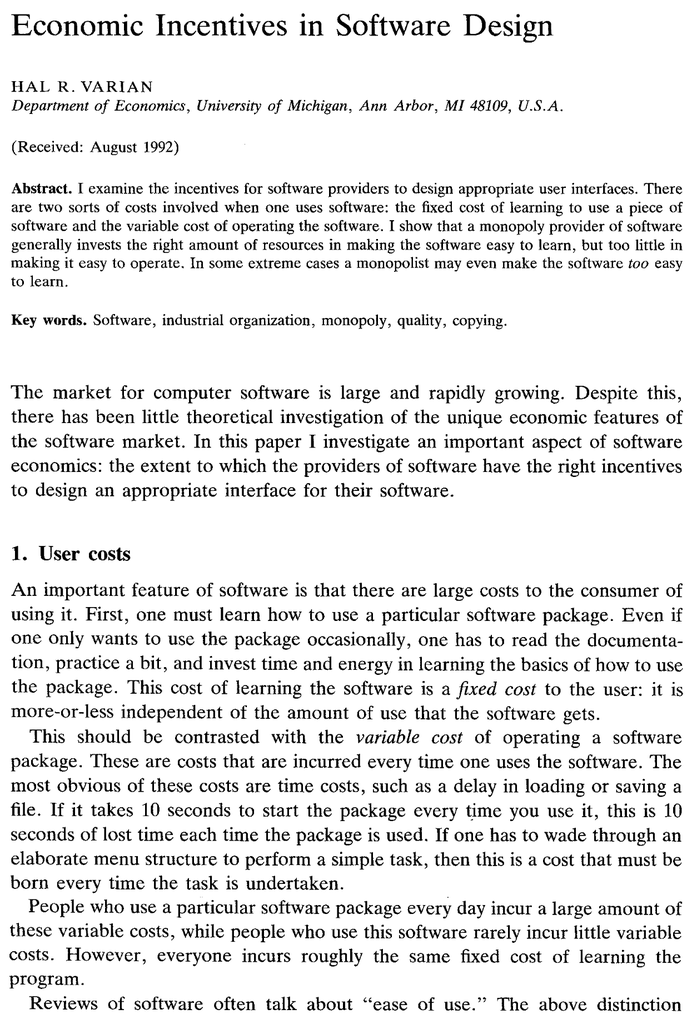

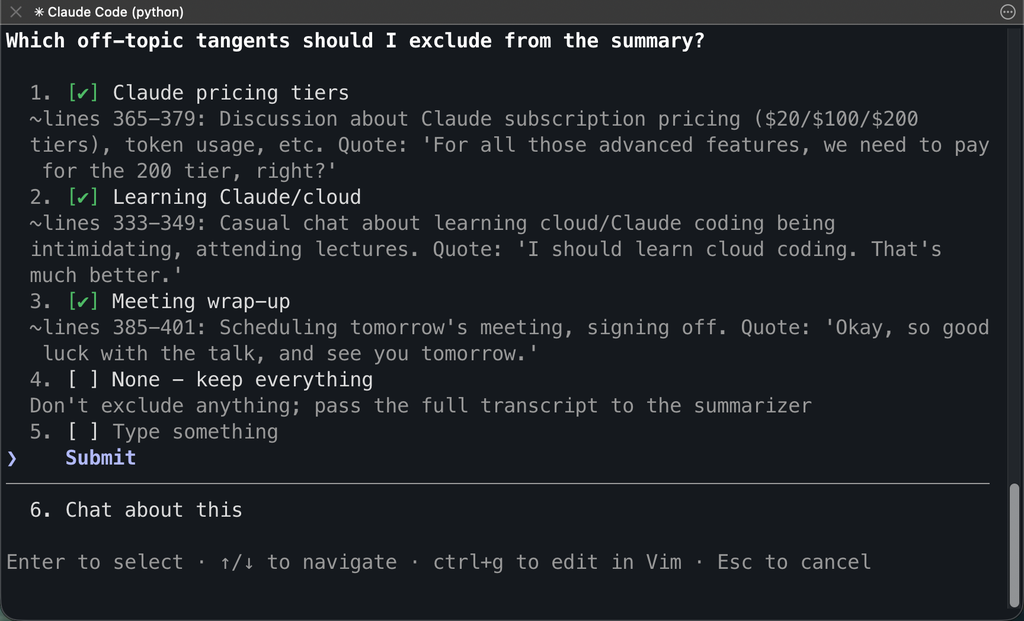

## Tools I’ve Built / Workflows I’ve Used

- Castle Adamant: github.com/fditraglia/castle-adamant
- Referee Recommender: [live](https://huggingface.co/spaces/fditraglia/referee-recommender), [source](https://github.com/fditraglia/econbase-abstracts)
- [Adventures with Claude Code and Qualtrics](https://unsolictedreviews.substack.com/p/adventures-with-claude-code-and-qualtrics)
- whisper-dictation: github.com/fditraglia/whisper-dictation
- econometrics.blog migration: [source](https://github.com/fditraglia/econometrics.blog)
- restatr / ivreg2r: restatr.com · github.com/restatr/ivreg2r

**Be creative; try things out! Claude can teach you new tricks**

## Wise words from Ada Lovelace

> It is desirable to guard against the possibility of exaggerated ideas that might arise as to the powers of the Analytical Engine. In considering any new subject, there is frequently a tendency, first, to *overrate* what we find to be already interesting or remarkable; and, secondly, by a sort of natural reaction, to *undervalue* the true state of the case, when we do discover that our notions have surpassed those that were really tenable.

[figure not shown]